# week 2 homework

Wouter Bakker

16-2-2020

During this week, I have discovered some methods to extend the music analysis beyond just Spotify. This has also led me to change my corpus. Since 2014, I have been keeping track of nearly every song I have listened to. I did this using a website called Last FM. Music I have listened to using desktop programs like iTunes and MusicBee are all included, as well as all my Spotify plays. Recording a play is called scrobbling, and this way I have “scrobbled” more than 118.000 played songs since around April 2014, a period of nearly 6 years. Using a package called “scrobbler” I have imported all my scrobbles to R, and saved it as a .csv file. The goal is to link all my scrobbles to the corresponding Spotify data. Luckily, a researcher at the University of Florida (Andrew Walker, 2019), has done research into patient-directed music interventions. For this, he linked patient’s Spotify accounts to Last FM, and with an R script he analysed the data. All the code he used is published online, and a rundown of his code [can be found here](https://andrewlouiswalker.com/2019/12/08/music-listening-history-analysis-through-spotify-last-fm-and-genius-apis-for-music-and-delirium-study-in-pediatric-intensive-care-unit/).

Starting out with some preliminary settings. Previously, I have already coverted the date into a proper date format, and extracted for every song the year, month, day, and hour the song was played. My research question will be focussed on how my music taste has developed over this period of time, so these time metrics will come in handy later on.

```r
rm(list=ls()) #removes variables from workspace
library(ggplot2)
#Data loading
setwd("C:/Users/Gebruiker/OneDrive/Psychologie/Jaar 3/Computational Musicology/Last FM")
scrobbles <- read.csv("scrobbles.main.csv")
```

Makes tabs out of artists.

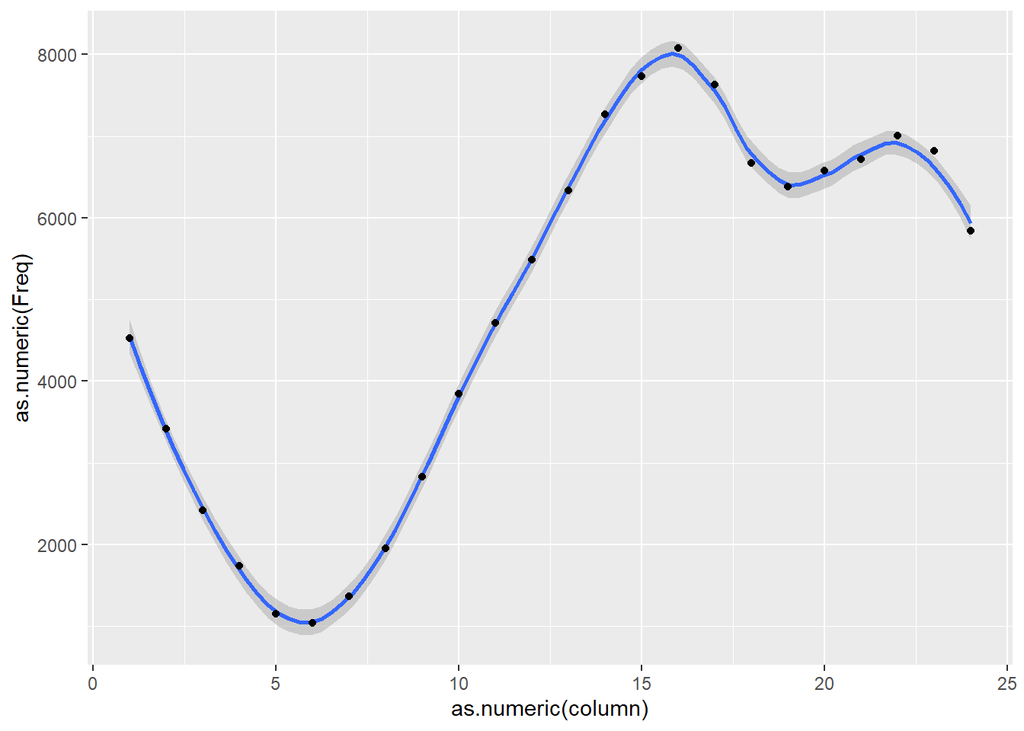

```r
#Tab of artists, albums and tracks, weekdays, dates etc.
tablate = function(column, FUN) {
  df = as.data.frame(table(column))
  df[order(df[,2], decreasing = FUN),]
  } #function for making tab out of given data, turning it into a dataframe and sorting it by frequency

tab.art = tablate(scrobbles$artist, T)
tab.alb = tablate(scrobbles$album, T)
tab.trc = tablate(scrobbles$song_title, T)
tab.year = tablate(scrobbles$year, F)
tab.month = tablate(scrobbles$month, F)
tab.day = tablate(scrobbles$weekday, F)
tab.hour = tablate(scrobbles$hour, F)
tab.daymonth = tablate(paste(scrobbles$year, scrobbles$month), F)

ggplot(tab.hour, aes(x = as.numeric(column), y = as.numeric(Freq))) +
  geom_smooth(span = 0.3) +
  geom_point()
```

This is the first interesting plot. It shows how much music I listen to during certain times of the day. From this you can see that the pattern of my music listening reflects my way of living. From evening till night it dips to its lowest point because I will usually be sleeping. Then it increases throughout the day (and as you can see, I have never been a morning person). During dinnertime at 18 it dips slightly, goes up a little after, and drops for the night again. Now it would be interesting to see if my habits have changed over the years.

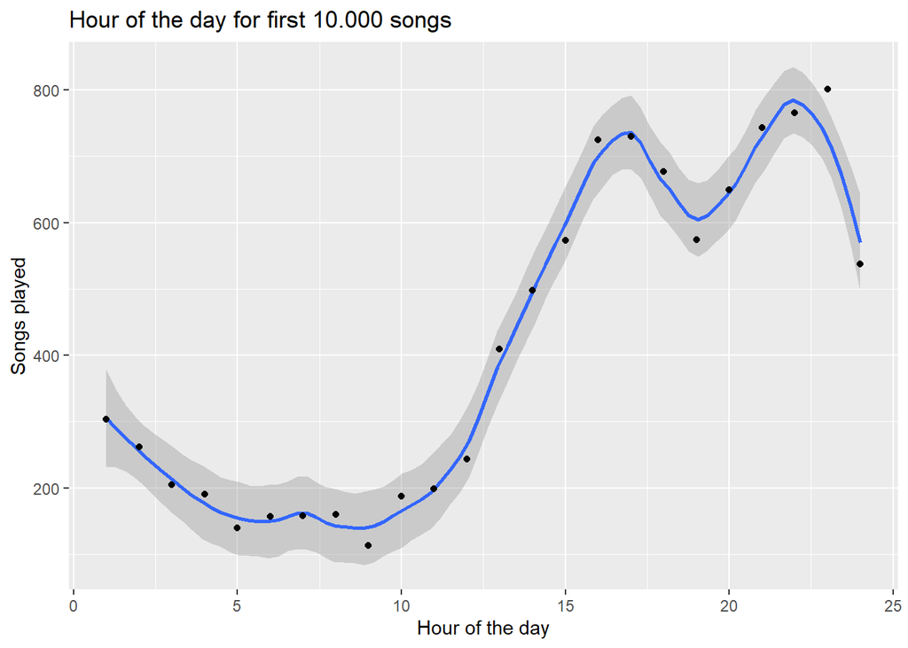

```r
#First sorts data by date.
bydate = scrobbles[sort(scrobbles$date, descending = F),]

#Subsets the first and last 10.000 plays
last = bydate[1:10000,]
first = bydate[(nrow(bydate)-10000):nrow(bydate),]
tab.first = tablate(first$hour, F)
tab.last = tablate(last$hour, F)



#Plots the column, containing the hours of the day, against the frequency it occurs.
#Also adds a smooth regression line

ggplot(tab.first, aes(x = as.numeric(column), y = as.numeric(Freq))) +
  geom_smooth(span = 0.3) +
  geom_point() +
  labs(title = "Hour of the day for first 10.000 songs", x = "Hour of the day", y = "Songs played")
```

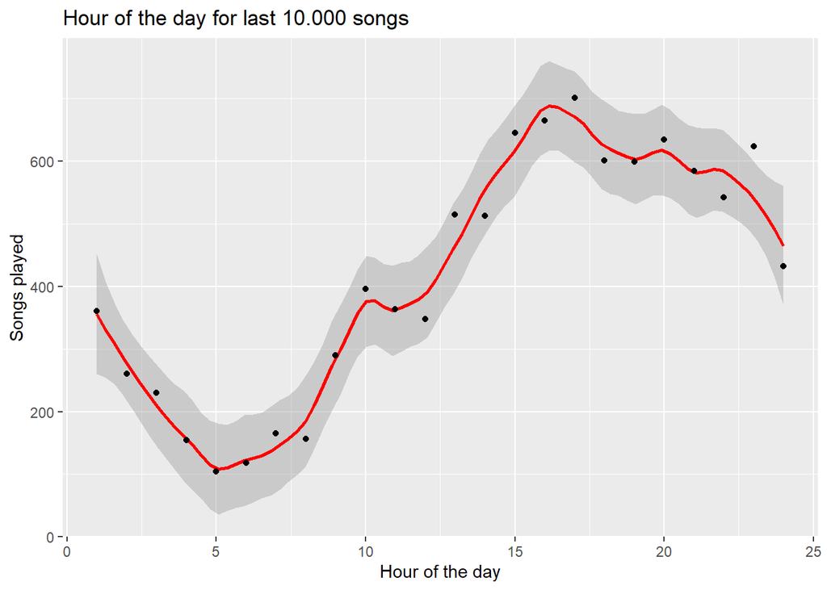

```r
ggplot(tab.last, aes(x = as.numeric(column), y = as.numeric(Freq))) +
  geom_smooth(span = 0.3, col = "red") +
  geom_point() +
  labs(title = "Hour of the day for last 10.000 songs", x = "Hour of the day", y = "Songs played")
```

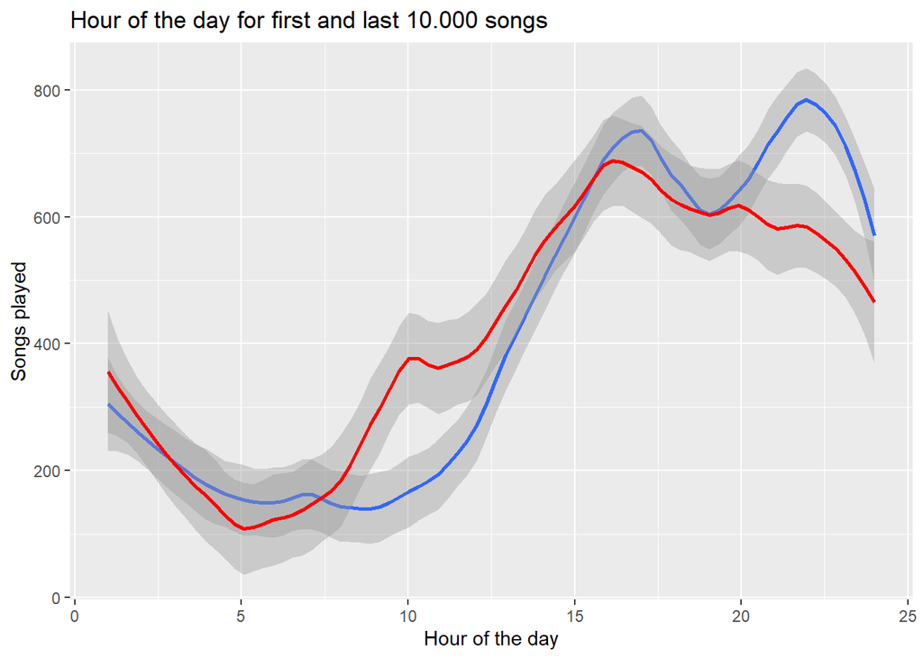

```r
ggplot(tab.first, aes(x = as.numeric(column), y = as.numeric(Freq))) +
  geom_smooth(span = 0.3) +
  labs(title = "Hour of the day for first and last 10.000 songs", x = "Hour of the day", y = "Songs played")+
  geom_smooth(data = tab.last, col = "red", span = 0.3)
```

```r
#Plot of both time periods
```

As you can see, the dip during dinnertime was much more pronounced for my first 10.000 plays, that occured from 2014-08-11 to 2015-02-14. Back then, I was still in high school, living with my parents, and we usually had dinner around 18:00. Of course I also had school every day from morning till the afternoon, so my life was much more structured. Since I’ve started studying and moved to Amsterdam, my schedule has become more unpredictable, and along with it also my music listening habits.

The big challenge if of course to combine the Last FM scrobbles with the Spotify data. I will try to do so using the research mentioned earlier.